# Typing Game Kit Documentation

Offline Documentation

This is the offline documentation. If you are using the most recent version, you might prefer the [online version](http://tediuminteractive.com/typing-game-kit/documentation/), as, it offers more searching capabilities and better navigation.

Feel free to send questions about the asset to support@tediuminteractive.com.

## Introduction

The *Typing Game Kit* a collection of assets for creating typing games in the Unity game engine. A typing game is a game where typing is an integral part of the game’s mechanics.

For instance, in the example game, *Asteroid Typing 2D* the player commands a ship that targets and shoots asteroids by typing various words. Each asteroid is associated with a text sequence. The player can target and shoot at the asteroids by typing the corresponding text sequence. Thus, the more swiftly the player can type, the longer their ship can avoid getting smashed by the asteroids.

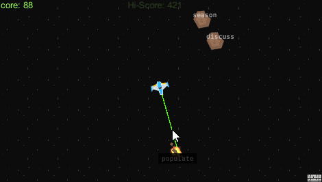

Asteroid Typing.

The following sections in this documentation will show how the assets in the *Typing Game Kit* work and how they fit together to build Typing Games.

Email Support

Send an email to support@tediuminteractive.com if you have any questions regarding the **Typing Game Kit**.

## Input Sequences

At the core of the *Typing Game Kit* is the `InputSequence`. In essence, it is a `MonoBehaviour` that represents a typeable text sequence.

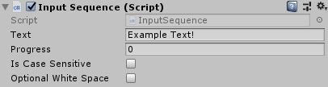

Input Sequence in the inspector.

### Typing and Targeting

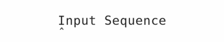

InputSequence being typed.

Before an input sequence may be typed, it has to become **targeted**.

A targeted sequence will either `accept` or `reject` received keyboard input. Received input is accepted if it matches the sequence’s text at its `progress` index. When an input sequence accepts input, its progress index increases. A targeted sequence automatically becomes untargeted once it has accepted all its text.

An input sequence may automatically become targeted. This occurs when: (1) input is received, (2) no other is sequence is targeted, and (3) the sequence would accept the received input. The `InputSequenceManager` manages the targeting and can be used to manually target/untarget the sequences.

#### Inspector Attributes

The `InputSequence` has the following attributes:

- **Text** - String that specifies the text of the input sequence.
- **Progress** - Integer that signifies how much its text has been received and accepted.
- **Is Case Sensitive** - Determines if the case of the input has to match when accepting/rejecting received input.
- **Optional White Space** - If enabled, whitespace will be optional and the next non-whitespace character would also be acceptable input.

### Events

#### InputSequence Events

The overarching pattern in using an `InputSequence` is to subscribe to its events and thereby invoking desired gameplay interactions.

For instance, in *Asteroid Typing 2D* the events of an input sequence are subscribed like the following:

```csharp
sequence.OnInputAccepted += delegate { _player.FireAt(asteroid); };
sequence.OnCompleted += delegate { asteroid.Explode(); };
```

In the code above, we define an event handler that will fire on the asteroid when input is `accepted`. Similarly, we add an event handler to `OnCompleted` to destroy the asteroid once the sequence has been completed.

Have a look at the scripting interface section for a listing of all available events.

#### InputSequenceManager events

Similarly to the `InputSequence` the `InputSequenceManager` has a number of events that can be subscribed to.

For example in *Asteroid Typing* will trigger the error sound in the following way.

```csharp
private void Awake()
{
    ///...
    InputSequenceManager.OnInputRejected += PlayErrorSound;
}

private void OnDestroy()
{
    InputSequenceManager.OnInputRejected -= PlayErrorSound;
}

private void PlayErrorSound()
{
      ///...
}
```

In this example, we subscribe to an event handler to `OnInputRejected` to play an error sound when input did not match any sequence. We also make sure to unsubscribe the event handler before it runs out of scope via the `OnDestroy` method.

Unsubscribe event handlers!

Unlike the `InputSequence`, the `InputSequenceManager` is a static class and its scope will probably remain long after its event handlers. It is advisable to unsubscribe an event handler before it runs out of scope.

### InputSequenceDisplays

The `InputSequenceDisplay` component is the default way of displaying the state of the input sequence.

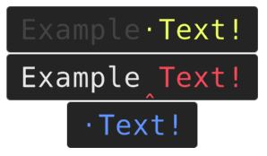

Three InputSequenceDisplays with different settings

TextMesh Pro

The `InputSequenceDisplay` depends on TextMesh Pro and its *Rich Text* formatting features. Make sure the font asset you use has all characters you want to display.

#### Inspector Attributes

The `InputSequenceDisplay` has several attributes that define how the input sequence will be displayed.

- **Sequence** - A reference to the sequence whose text will be displayed.
- **Text** - A Text Mesh Pro component that displays the text output.
- **Completed Color** - Color of the completed portion of the text.
- **Remaining Color** - Color of the remaining text
- **Hide Completed Text** - If enabled the completed portion of the text will be hidden.
- **Position Indicator** - The specified symbol will be drawn to indicate the next position in the sequence.
- **Space Replacement** - Specifies the symbol to use to replace the space character when its input is required.

Adjusting the position indicator

By default, the *position indicator* is displayed via the non-spacing character U+032D. The indicator’s position can be adjusted in Text Mesh Pro’s SDF font asset’s inspector.

### Example Scene

The *Input Sequence* example scene combines all the features in this section and can be found within the `Typing Game Kit/Scenes/Examples/Input Sequence` folder. The scene contains an `InputSequence`, `InputSequenceDisplay`, and `TextChanger` script that changes the sequence’s text once it has been completed.

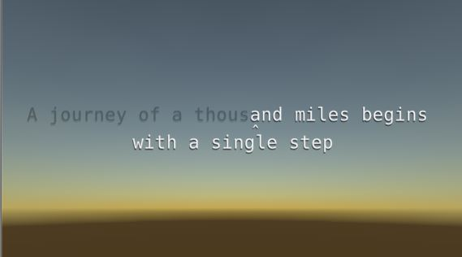

Single Sequence Example scene.

## Sequence Overlay

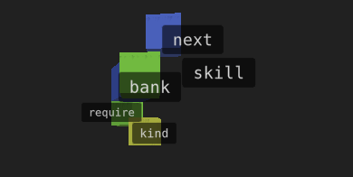

The sequence overlay in action.

The `SequenceOverlay` is located inside an overlay canvas and manages the positioning and creation of input sequence entities.

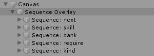

SequenceOverlay with several sequences overlay entities.

The sequence overlay has the following attributes in the inspector:

- The **Settings** defines the `OverlaySettings` to use.
- The **Entity Bounds** reference a `RectTransform` that defines the bounds of the sequence entities.
- The **Camera** reference defines what camera to use when projecting the sequences’ position in the canvas. If undefined the scene’s default camera will be used.
- The **Sequence Prefab** references the `SequenceOverlayEntity` to instantiate when creating a new sequence.

Screen Space - Overlay

The SequenceOverlayManager needs to be inside a **Canvas** with the **Screen Space - Overlay** rendering mode to function properly.

### Sequence Overlay Entities

The `SequenceOverlayEntity` component is attached to a game object that visualizes an `InputSequence` in the sequence overlay. The sequence overlay entity has its input sequence as a required component and will be defined on the same object.

The `SequenceOverlayEntity` has the following attributes.

- The **Rect** specifies the `RectTransform` to use when avoiding overlap with other entities.
- The **Target** defines the current in-game `Transform` that the entity will overlay and following.

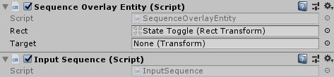

SequenceOverlayEntity with its InputSequence.

#### Entity Prefabs

Several sequence overlay entity prefabs are already defined in the *Typing Game Kit*. The prefabs are composed of two `InputSequenceDisplay` components that are toggled depending on whether their `InputSequence` is targeted or not.

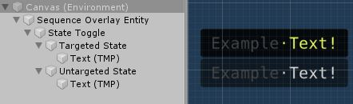

A SequenceOverlayEntity prefabs.

#### Creating Sequence Overlay Entities

Once the `SequenceOverlayEntity` prefab has been assigned to the `SequenceOverlay` the overlay sequences can be created by calling the sequence overlay’s `CreateSequence` method.

```csharp
InputSequence sequence = sequenceOverlay.CreateSequence(text, targetTransform);
```

This will instantiate a sequence with the given text and target. The sequence position in the canvas will be matched with its target’s position. `CreateSequence` will return the entity’s `InputSequence`.

### Overlay Settings

The `SequenceSettings` contains The following attributes:

- **Remain within bounds** - If toggled sequences Entities will be restricted to the sequence overlay’s bounding rect.
- **Movement Smoothness** - Defines how smooth the movement of the sequences will be. Set to zero to disable.
- **Avoidance Strength** - Determines how much the sequences will be repelled from each other.
- **Use Distance Scaling** - Enables/disables the scaling of entities depending on their target’s distance from the camera.

Distance Scaling Details

If distance scaling option is enabled then sequence entities will be scaled based on their distance to the camera according to the following scheme:

- If closer than **Closest Distance** the entity will have the **Closest Distance Scale**.
- If further away than the **Furthest Distance** the entity will have the **Furthest Distance Scale**.
- If in between the furthest and closest distances the scale will be linearly interpolated between the two scales.

### Example Scene

The `Typing Game Kit/Scenes/Examples/Sequence Overlay` folder contains a scene that illustrates the usage of the Sequence Overlay. In the scene, the `SequenceOverlayExample` script will spawn several invisible objects and attaches a sequence to each of them via the sequence overlay. Once a sequence has been typed another one will appear.

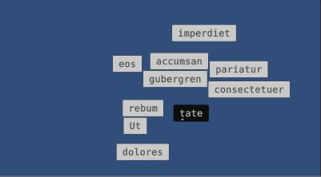

The Sequence Overlay example scene.

Additional Examples

Asteroid Typing 2D and Alien Typing 3D both use the Sequence Overlay.

### Prefabs

Ready to go prefabs for the overlay sequence system can be found in the `Typing Game Kit/Scenes/Examples/Sequence Overlay/Prefabs` folder.

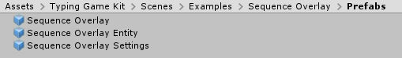

The default prefabs.

## Text Collections

A `TextCollection` is a `ScriptableObject` that can be created to facilitate the generation of text to put into input sequences. The text collection’s texts are extracted from one or more source files.

### Text Extraction

The texts in a Text Collection are gathered by one or more source files. In between the text collection and a source file sits a text extractor that will split the source file into smaller text chunks before they are added to the collection.

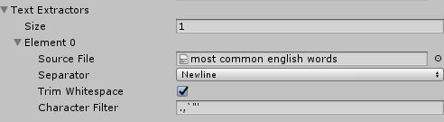

text extractor

Each text extractor has a number of attributes that will determine how the source file’s will be split up.

- The **Source File** specifies the source text to extract words from.
- The **Separator** defines what separator to use when splitting the source text up.
- The **Trim Whitespace** toggle determines if whitespace characters should be removed from the edges of the text or not.
- The **Char Filter** string contains a collection of characters that will be filtered out of the source text.

### Statistics

The text collection’s inspector will display some statistics that will give you an idea about its content. It will show the number of text in the collection, a breakdown of the distinguishable initials in the text, and several random text samples.

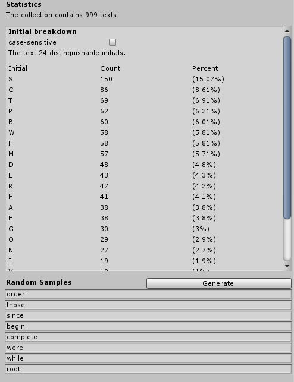

Text Collection statistics

### Selecting Texts

If we have a reference to a text collection we can pick a random text from the collection like this:

```csharp
string text = textCollection.PickRandomText();
```

However, if we are selecting texts for input sequences, it’s often desirable to have each text begin with a unique initial character. If each sequence has a unique initial, the player can predict which sequence will become targeted. In this case, we can use the `FindUniquelyTargetableText` method to find a text that is uniquely targetable among the existing input sequences:

```csharp
string text = textCollection.FindUniquelyTargetableText();;
```

Creating a new WordCollection

A new `WordCollection` can be created from the `Assets/Create/Typing Game Kit` menu.

## Virtual Keyboard

To help create typing games for mobile devices, the *Typing Game Kit* includes an “Advanced” and a “Simple” keyboard prefab. The *Advanced Keyboard* prefab is similar to what can be found on most mobile devices and supports a wider array of ASCII characters than the simpler *Simple Keyboard* prefab. The prefabs are contained in the `TypinGameKit/Assets/Virtual Keyboard/` folder.

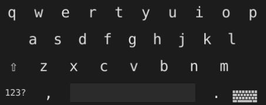

The Advanced Virtual Keyboard

### Example Scene

An example scene that illustrates how the virtual keyboard can be configured to scale with most mobile resolutions can be found in the `Typing Game Kit/Scenes/Examples/Virtual Keyboard` folder.

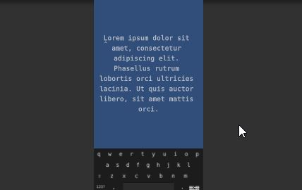

The Virtual Keyboard scaling example.

Additional Examples

Asteroid Typing 2D and Alien Typing 3D also include the virtual keyboard.

## Example Games

### Asteroid Typing 2D

*Asteroid Typing 2D* illustrates the implementation of a simple top-down typing game. Asteroids will be flung at the player’s ship whilst the player frantically shoots at the asteroids to survive.

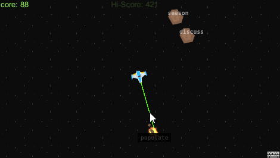

Asteroid Typing.

#### Scene Overview

The *Asteroid Typing 2D* game uses the Sequence Overlay which is located inside the scene’s canvas object.

The game is principally controlled by the `AsteroidGameManager` script, located on the scene’s *Game Manager* object. The asteroids’ creation, spawn rate, speed, and sequences are controlled by the `AsteroidSpawner` located on the *Asteroid Spawner* object. The `PlayerShip` script attached to the *Player Ship* object triggers the ship’s laser animations and sounds.

Once the player ship inevitably explodes the `GameManager` will pause the game and show the results panel in the canvas. The Results panel will show the resulting score, high score, and give the player the option to try again.

### Alien Typing 3D

Alien Typing demonstrates the implementation of a rail-based typing game. The player moves through a space ship and shoots at hostile aliens as they approach.

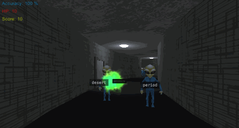

Alien typing.

#### Scene Overview

The *Alien Typing 3D* game utilizes the sequence overlay to show the input sequences next to enemies. The sequence overlay is defined inside the canvas. The game’s flow is controlled by the `AlienGameManager` on the `Game Manager` object.

The player and camera are located inside the `Player Path` object. The player’s movement path is defined by an animation. Events along the path animation will trigger where the player will stop and fight the enemies in the next section. The `PlayerPath` script manages the player path events and is located on the `Player Path` object. The `PlayerPath` keeps references to the enemy sections that will be triggered in order along the animation path. The enemy sections are located inside the `Enemy Sections` object. Each `Enemy` that is a child of an `EnemySection` object will attack the player once that section is triggered.

Once the player dies or completes the level the `GameManager` will pause the game and show the results panel and let the player have another go.

## Scripting Interface

This section presents an overview of the scripting interfaces for the core components in the *Typing Game Kit*.

### InputSequence

Represents a sequence of texts that may be typed.

#### Events

InputSequence.OnCompleted

Is raised when the sequence has been completed.

InputSequence.OnInputAccepted

Is raised when the sequence receives matching input.

InputSequence.OnInputRejected

Is raised when the sequence receives input that does not match.

InputSequence.OnRemoval

Is raised when a sequence is set for removal.

InputSequence.OnTargeted

Is raised when the sequence has been targeted.

InputSequence.OnTextUpdated

Is raised when the sequence’s text has been altered.

InputSequence.OnUntargeted

Is raised when the sequence has been untargeted.

#### Properties

InputSequence.AcceptableInputs

Returns the inputs that can currently be accepted by the sequence.

InputSequence.CompletedText

Returns the portion of the text that has been accepted by the sequence so far.

InputSequence.IsCaseSensitive

Determines if the case of input is regarded when accepting/rejecting input.

InputSequence.IsCompleted

Returns true if the sequence has been typed to completion.

InputSequence.IsTargeted

Returns `true` if the sequence is targeted else `false`.

InputSequence.LastProcessedInput

The last input fed into the sequence.

InputSequence.Progress

The number of characters that have been accepted by the sequence.

InputSequence.RemainingText

Returns the portion of the text that is remaining of the sequence.

InputSequence.Text

The sequence’s text content.

InputSequence.OptionalWhiteSpace

If enabled whitespace is optional and the next non-whitespace character is acceptable input.

#### Methods

InputSequence.DoesAcceptInput

Returns true if the sequence would accept the given input.

InputSequence.ReceiveInput

Makes the input sequence receive and either ‘accept’ or ‘reject’ the provided input.

InputSequence.Remove

Destroys the sequence.

InputSequence.ResetProgress

Resets the progress of the sequence.

InputSequence.Target

Targets the sequence.

InputSequence.Untarget

Untargets the InputSequence.

### InputSequenceManager

Controls what and how input is fed into the input sequences.

#### Events

InputSequenceManager.OnInputAccepted

Is raised when input successfully matched any sequence.

InputSequenceManager.OnInputRejected

Is raised when input failed to match any sequence.

InputSequenceManager.OnSequenceCompleted

Is raised when any sequence was completed.

#### Properties

InputSequenceManager.AcceptableInputs

Returns all the inputs that would be accepted by at least one sequence.

InputSequenceManager.LatestProcessedInput

The latest processed input.

InputSequenceManager.SequenceCount

Returns the number of registered input sequences.

InputSequenceManager.Sequences

Returns all the registered input sequences.

InputSequenceManager.TargetedSequences

Returns the targeted sequences.

InputSequenceManager.ReceivingSequences

Sequences that currently may receive input.

#### Methods

InputSequenceManager.ClearTargetedSequences

Clears the targeted sequences.

InputSequenceManager.RegisterSequence

Registers a sequence with the manager and enable it to receive keyboard input.

InputSequenceManager.RemoveAllSequences

Marks registered sequences for removal.

InputSequenceManager.TargetSequence

Targets the given input sequence.

InputSequenceManager.UntargetSequence

Untargets the given input sequence.

InputSequenceManager.UnregisterSequence

The sequence will no longer receive input.

InputSequenceManager.ProcessInput

Forces the manager to process input unless it has already done so this frame.

### SequenceOverlay

Instantiates and manages the Sequence Overlay.

#### Properties

SequenceOverlay.SequenceEntityPrefab

The prefab to use when instantiating the overlay entities.

#### Methods

SequenceOverlay.CreateSequence

Instantiates a new `SequenceOverlayEntity` prefab and returns its corresponding `InputSequence`

### TextCollection

Extract texts from text files and index the texts by their initial character.

#### Properties

TextCollection.InitialsBreakdownByCase

If true the statistics separate the initials with different case.

TextCollection.Texts

All available text in the collection.

#### Methods

TextCollection.EvaluateTexts

Reevaluates the extracted strings.

TextCollection.FindUniquelyTargetableText

Attempts to return a text with a unique initial among the other registered input sequences’ texts.

TextCollection.Initials

TextCollection.PickRandomText

Picks a random text from the collection.

TextCollection.TextsByInitial

Returns all the text with the specified initial.

TextCollection.UniqueInitialInput

Returns a text that has a unique initial among the other provided texts. Returns null if no such text exists.